# An Exploration of Feature Importance

###### Introduction:

Data scientists (including budding data scientistics like myself) often find modeling to be the most fun and rewarding part of the data science process. But gaining insights into the model's features, either for business intelligence or model improvement purposes, is an overlooked, yet critical step. Feature importance is the process of figuring out which features have the most predictive power (i.e. most importance) for your model.

In this report, I will outline several feature importance techniques, visualize these strategies, and investigate the variance and statistical significance of the scores. I will be using the popular Boston Dataset in my investigations. The target variable is the median value of homes in $1000's.

## Feature Importances only from the X, y Relationship

One type of feature importances only uses the relationship between X and y to infer importance of a variable. The first is Spearman's Rank Correlation.

###### Spearman's Rank Correlation Coefficient

This method measures the rank correlation between each individual X variable and the target y. You first separately rank the values in x and y (there are many ways to deal with ties--I used the minimum) and then calculate Pearson's correlation coefficient on the ranked variables. This technique measures the monotonic relationship between x and y and is not influenced by outliers. A problem with this method is that it measures single feature relevance, and if two features, x1 and x2, are highly correlated then they will have similar Spearman's importances scores, even thought only one may actually be important in the model.

Here is the results of Spearman's Rank on the Boston dataset.

```python
spear = spearmans_rank_corr(X, y)
spear.T
```

|  | 0 | 1 | 2 | 3 | 4 | 5 | 6 | 7 | 8 | 9 | 10 | 11 | 12 |
| --- | --- | --- | --- | --- | --- | --- | --- | --- | --- | --- | --- | --- | --- |
| Feature | LSTAT | RM | NOX | CRIM | AGE | TAX | INDUS | PTRATIO | DIS | ZN | RAD | B | CHAS |
| Importance | 0.853043 | 0.634616 | 0.561363 | 0.559993 | 0.549554 | 0.543672 | 0.538547 | 0.504274 | 0.446806 | 0.437777 | 0.306905 | 0.223056 | 0.139252 |

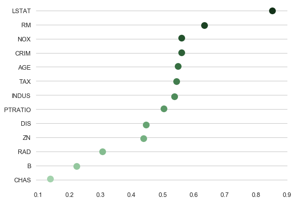

###### PCA Importance

Another possible method, which actually doesn't even use the target varaible y, is to apply Principal Component Analysis to the X features, and take the individual 'loads' of the first component as the importance measures. This is a quick and easy technique, but not the most accurate (at least for the Boston data per my findings). Here are the results for PCA importance.

```python
pca = PCA_importance(X)
pca.T
```

|  | 0 | 1 | 2 | 3 | 4 | 5 | 6 | 7 | 8 | 9 | 10 | 11 | 12 |
| --- | --- | --- | --- | --- | --- | --- | --- | --- | --- | --- | --- | --- | --- |
| Feature | INDUS | NOX | TAX | DIS | RAD | AGE | LSTAT | ZN | CRIM | PTRATIO | B | RM | CHAS |
| Importance | 0.346672 | 0.342852 | 0.338469 | 0.321544 | 0.319793 | 0.313671 | 0.30976 | 0.256315 | 0.250951 | 0.204942 | 0.202973 | 0.189243 | 0.00504243 |

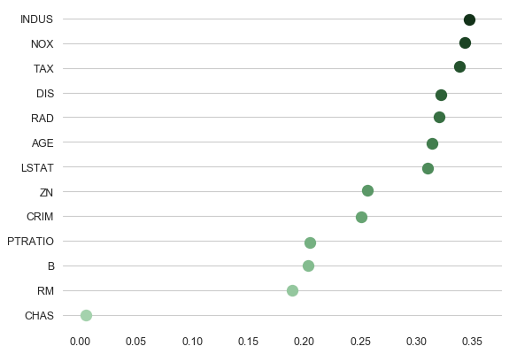

###### Minimal-Redundacy-Maximal-Relevance (mRMR)

Another technique is to measure the relevance of a variable, relationship between x and y, and the redundancy of the variable, relationship between x and the other x's, and compute the mRMR. The formula for this is:

$$J_{RMR}(x_{k}) = I(x_{k},y) - \frac{1}{|S|}\sum_{x_{j}\in S} I(x_{k}, x_{j})$$

The function $I(x_{k}, \theta)$ is any measaure of importance, but I will use Spearman's Rank for simplicity. The idea is to penalize the relevance with the average redundancy. mRMR can also be used as a feature selection algorithm, where you add the highest mRMR feature (where S is the current feature space) each iteration. This method is good for parsing out the individual effect of a feature on the target.

Here are the mRMR importances on the Boston Data. Note that it is possible to get negative importances, meaning the variable is more redundant that relevant.

```python
mrmr = mRMR(X,y)
mrmr.T
```

|  | 0 | 1 | 2 | 3 | 4 | 5 | 6 | 7 | 8 | 9 | 10 | 11 | 12 |
| --- | --- | --- | --- | --- | --- | --- | --- | --- | --- | --- | --- | --- | --- |
| Feature | LSTAT | RM | PTRATIO | TAX | CHAS | AGE | INDUS | ZN | CRIM | NOX | B | RAD | DIS |
| Importance | 0.371491 | 0.353959 | 0.232973 | 0.100931 | 0.0758504 | 0.0581113 | 0.043328 | 0.0198433 | 0.0133134 | 0.0101874 | -0.00495342 | -0.0339512 | -0.066015 |

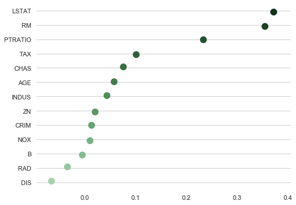

###### Comparison of Methods So Far

Let's compare how the top $n$ features of each feature importances method do when predicting the target. Below is a plot of the R2 scores (average of 5-fold CV) using the top $n$ features from each method, where $n = 1, 2, ... , 8 $. The model of choice is a Random Forest Regressor with 80 trees, 10 min samples per leaf, and sqrt max features.

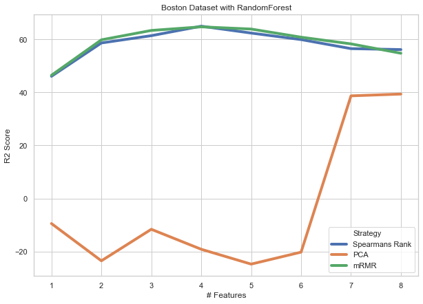

As you can see, Spearman's Rank and mRMR have very similar results, but PCA is quite lacking for this dataset. This type of plot can also tell you how many features is necessary to maximize the predicitve power of the model. For much larger datasets with more rows and more features, it would be worthwhile to know you can get similar results by using fewer features.

## Feature Importances using a Model

The other type of feature importance uses the results of a model--calculate the drop in metric score once a feature is removed (drop column) or scrambled (permutation).

###### Drop Column Importance

The idea of drop column importance is to measure the difference in metric score from the full model and a model with a feature dropped. First, train a model on all the features and get a baseline metric score from the validation set, then iteratively, drop a column, re-train the model without that column and get a metric score on the validation set. The difference of the baseline score to each dropped column metric score is the importance measure of that column. However, this procedure is computationally expensive because you have to train the model n_features + 1 number of times.

Here are the results of drop column importance on the Boston data.

```python
drop_col = drop_column(rf, X_train, X_val, y_train, y_val)
drop_col.T
```

|  | 0 | 1 | 2 | 3 | 4 | 5 | 6 | 7 | 8 | 9 | 10 | 11 | 12 |
| --- | --- | --- | --- | --- | --- | --- | --- | --- | --- | --- | --- | --- | --- |
| Feature | RM | LSTAT | NOX | AGE | INDUS | TAX | DIS | PTRATIO | RAD | ZN | CHAS | CRIM | B |
| Importance | 0.0794594 | 0.0727168 | 0.0142617 | 0.00831771 | 0.00614341 | 0.00296216 | 0.00226174 | 0.000762441 | 0.000497372 | -0.00113022 | -0.00124653 | -0.00191671 | -0.00239836 |

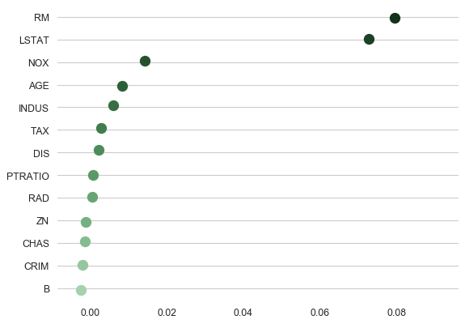

###### Permutation Importance

Permutation importance is similar to drop column importance that it iteratively 'drops' a column and re-computes the metric score compared to the baseline. However, permutation importance solves the computationally expensive problem by simply randomly permuting a column then re-computing the metric score. The model is only trained once for the baseline, and the column drop is simulated by randomizing the column. Randomly shuffling the column breaks all relationships and essentially makes that column's predictive power zero.

Here are the results of permutation importance for Boston.

```python
perm = permutation(rf, X_train, X_val, y_train, y_val)
perm.T
```

|  | 0 | 1 | 2 | 3 | 4 | 5 | 6 | 7 | 8 | 9 | 10 | 11 | 12 |
| --- | --- | --- | --- | --- | --- | --- | --- | --- | --- | --- | --- | --- | --- |
| Feature | RM | LSTAT | PTRATIO | NOX | TAX | CRIM | INDUS | DIS | B | AGE | RAD | CHAS | ZN |
| Importance | 0.304618 | 0.289697 | 0.0492171 | 0.0399295 | 0.0289355 | 0.015096 | 0.0145273 | 0.009115 | 0.00718461 | 0.00502022 | 0.00181645 | -6.69023e-05 | -0.00048406 |

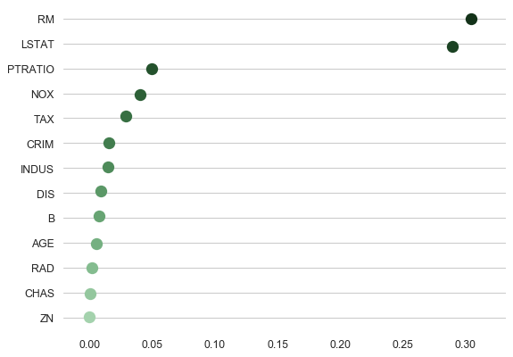

###### A Comparison of our Techniques So Far

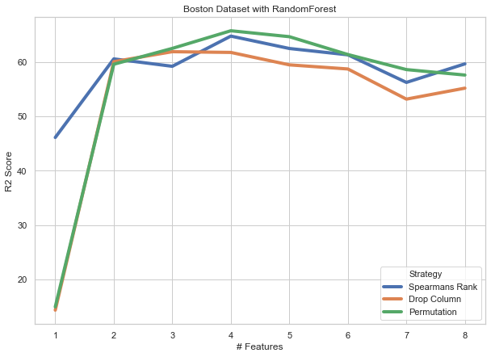

We notice that drop column and permutation are very similar for all values of n features, and that the R2 scores for >=2 features chosen by the three strategies are basically the same.

## Measures of Variance and Statistical Significance

###### Variance

Once we have measures of feature importance, one should consider how the results change when repeated over and over again. If we consider our dataset a sample of the actual population dataset, computing the feature importances on a dataset is the same as computing a parameter for one sample of a population. From the Law of Large numbers, we know that as we repeat an experiment many times, the average of the parameter will trend towards the expected value of, or population, paramter. In our case, the parameter is feature importances. To simulate getting a different sample of data, we can bootstrap (sample n rows with replacement).

In my example, I bootstrapped the Boston data 250 times, and computed the mRMR importances for each sample. The bar plot below shows the 'true' feature importance and the spread, or variance, of the importances. The error bars denote $\pm1$ standard deviation from the mean.

```python
var = variances(X, y, 250)
```

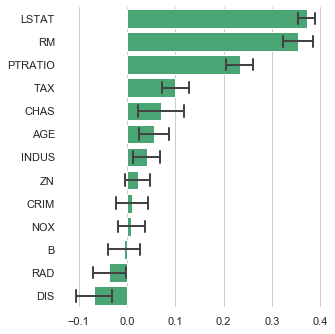

This shows that LSTAT, RM, and PTRATIO are consistenly the most important features across all bootstrapped samples, and that they don't vary wildly.

###### Statistical Significance

The ability to compute the variance of the importances is great, but can we actually measure if a feature is statistically significant? The answer is yes. If we can create a null distribution for each feature importance, then we can empirically compute a p-value (probability the feature importance is from the null distribution) for each feature. The process goes like this,

1. Compute the real, baseline, feature importances using the normal X, y dataset
2. Iteratively for n_trials (create the null distribution):
   1. Shuffle the y values
   2. Compute feature importances using X and shuffled y
   3. Compare these importances to the baseline
3. Count the number of times the importances on the shuffled data exceed the baseline importances for each feature
4. This count/n_trials is the empirical p-value for each feature

If the p-value is greater than some threshold (usually 5%), then that feature is not statistsically significant.

In my example below, I used permutation importance as my importance measure.

```python
baseline, importances, p_val = empirical_p_value(rf, X_train, X_val, y_train, y_val, 500)
```

The p-values for each feature are (with 500 trials):

|  | CRIM | ZN | INDUS | CHAS | NOX | RM | AGE | DIS | RAD | TAX | PTRATIO | B | LSTAT |
| --- | --- | --- | --- | --- | --- | --- | --- | --- | --- | --- | --- | --- | --- |
| 0 | 0.056 | 0.094 | 0.006 | 0.292 | 0.0 | 0.0 | 0.228 | 0.024 | 0.198 | 0.082 | 0.0 | 0.196 | 0.0 |

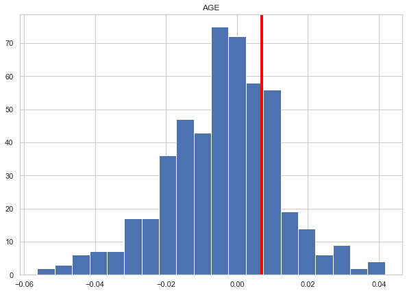

In contrast to AGE, the null distribution and real importance score for LSTAT is presented below. As you can see, the importance score with random y never exceed the true importance (even with 500 trials), so we can be extremely confident that LSTAT is an important feature.

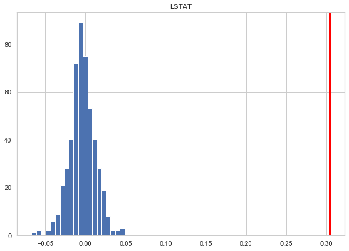

## Conclusion:

A data scientists job is not over once they fit a good model. Some of the most crucial insights can come from a post-hoc analysis of the model and it's features. The methods described in this report, like Spearman's Rank correlation, permutation importance, and statistical significance, can help one explain how and why a model predicts the way it does. Those explanations are critical for business intelligence and can help facilitate discussions to further improve the model.. which is the fun part, right?